**SYS 6018 | Fall 2020 | University of Virginia**

# km5ar

### Problem 9.1: Interestingness

Suppose we have market basket data consisting of 100 transactions and 20 items. Assume the support for item {$a$} is 20%, support for item {$b$} is 85%, and support for itemset {$a,b$} is 15%.

1. What is the confidence of the rule {a} $\rightarrow$ {b}?

$$C(A \rightarrow B)=\frac{S(A, B)}{S(A)} = \frac{\operatorname{Pr}(A \subseteq T, B \subseteq T)}{\operatorname{Pr}(A \subseteq T)}=P(B \subseteq T \mid A \subseteq T) = \frac{0.15}{0.2} = 0.75$$

2. Will the apriori algorithm find this rule (interesting) if the confidence threshold (minconf) is $c=.60$ and the support threshold (minsup) is $s=.10$?

The apriori algorithm find this rule interesting due to $c(a \rightarrow b) = 0.75 > 0.6$ and $s(a,b) = 0.15$.

3. Find the *lift* of this rule.

$$\begin{aligned}
L(A, B) =\frac{C(A \rightarrow B)}{S(B)} = \frac{0.15}{0.2*0.85} = 0.882352941\end{aligned}$$

4. Find the *addedValue* of this rule.

$$\begin{aligned}
\mathrm{AV}(A \rightarrow B) &=C(A \rightarrow B)-S(B) \\
&=\mathrm{PS}(A, B) / S(A) \\
& \triangleq \operatorname{Pr}(B \mid A)-\operatorname{Pr}(B) \\
& = 0.75 - 0.85 = - 0.1
\end{aligned}$$

5. Find the *leverage/PS* of this rule.

$$\operatorname{PS}(A, B)=S(A, B)-S(A) S(B) = 0.15 - 0.2*0.85 = -0.02$$

6. Describe the nature of the relationship between items {a} and {b} according to *lift*, *addedValue* and *leverage/PS*. What observation can you draw from parts (b) and (c-e)?

because the Left is smaller than 1 which indicates negative association between a and b, people who buy a will tend to not buy b, or people who buy b will not tend to buy a. Then the addedValue supports this idea because it is slityly negative. however the leverage(range:[-1:1]) is slighty negitive with the value of -0.02, which also suggests there is a negative association.

7. Let $p(a)$, $p(b)$, and $p(a,b)$ be the actual probabilities of observing items {a}, {b}, and {a,b} respectively in a transaction. What is the expected confidence rule {a} $\rightarrow$ {b} if a and b are independent?

since we are assuming a and b are independent,

$$\frac{P(a \rightarrow b)}{(a)} =P(b|a)$$

### Problem 9.2: Online Retail

The website http://archive.ics.uci.edu/ml/datasets/online+retail describes some transactional data from an online retailer.

1. Download the [excel file](http://archive.ics.uci.edu/ml/machine-learning-databases/00352/Online%20Retail.xlsx) to your machine and read it into R.

```r
data.dir = "/Users/cory/Desktop/6018_hw9"
X = read_excel(file.path(data.dir, "Online Retail.xlsx"))
X
```

```
#> # A tibble: 541,909 x 8
#>    InvoiceNo StockCode Description Quantity InvoiceDate         UnitPrice
#>    <chr>     <chr>     <chr>          <dbl> <dttm>                  <dbl>
#>  1 536365    85123A    WHITE HANG…        6 2010-12-01 08:26:00      2.55
#>  2 536365    71053     WHITE META…        6 2010-12-01 08:26:00      3.39
#>  3 536365    84406B    CREAM CUPI…        8 2010-12-01 08:26:00      2.75
#>  4 536365    84029G    KNITTED UN…        6 2010-12-01 08:26:00      3.39
#>  5 536365    84029E    RED WOOLLY…        6 2010-12-01 08:26:00      3.39
#>  6 536365    22752     SET 7 BABU…        2 2010-12-01 08:26:00      7.65
#>  7 536365    21730     GLASS STAR…        6 2010-12-01 08:26:00      4.25
#>  8 536366    22633     HAND WARME…        6 2010-12-01 08:28:00      1.85
#>  9 536366    22632     HAND WARME…        6 2010-12-01 08:28:00      1.85
#> 10 536367    84879     ASSORTED C…       32 2010-12-01 08:34:00      1.69
#> # … with 541,899 more rows, and 2 more variables: CustomerID <dbl>,
#> #   Country <chr>
```

2. There are many quality problems with this dataset, but we will only address two of them. Remove all of the rows with missing Description values (NAs) and remove any duplicate items in a single transaction. Print the first 10 rows of the resulting data.

```r
# remove NAs and remove duplicate items
#X_b = X[!is.na(X$Description),] %>% distinct()

X_b = X %>% filter(!is.na(Description)) %>%
  distinct(InvoiceNo, StockCode, .keep_all = TRUE)
head(X_b, n=10)
```

```
#> # A tibble: 10 x 8
#>    InvoiceNo StockCode Description Quantity InvoiceDate         UnitPrice
#>    <chr>     <chr>     <chr>          <dbl> <dttm>                  <dbl>
#>  1 536365    85123A    WHITE HANG…        6 2010-12-01 08:26:00      2.55
#>  2 536365    71053     WHITE META…        6 2010-12-01 08:26:00      3.39
#>  3 536365    84406B    CREAM CUPI…        8 2010-12-01 08:26:00      2.75
#>  4 536365    84029G    KNITTED UN…        6 2010-12-01 08:26:00      3.39
#>  5 536365    84029E    RED WOOLLY…        6 2010-12-01 08:26:00      3.39
#>  6 536365    22752     SET 7 BABU…        2 2010-12-01 08:26:00      7.65
#>  7 536365    21730     GLASS STAR…        6 2010-12-01 08:26:00      4.25
#>  8 536366    22633     HAND WARME…        6 2010-12-01 08:28:00      1.85
#>  9 536366    22632     HAND WARME…        6 2010-12-01 08:28:00      1.85
#> 10 536367    84879     ASSORTED C…       32 2010-12-01 08:34:00      1.69
#> # … with 2 more variables: CustomerID <dbl>, Country <chr>
```

3. Find the number of transactions and number of items using *InvoiceNo* for transactions and *Description* as items (i.e., ignore the *StockCode* column).

```r
# the number of transactions using *InvoiceNo*
Nunber_of_Transactions = n_distinct(X_b$InvoiceNo)
Nunber_of_Transactions
```

```
#> [1] 24446
```

```r
# number of items using *Description*
Nunmber_of_Items =n_distinct(X_b$Description)
Nunmber_of_Items
```

```
#> [1] 4211
```

There are 24446 of transactions and 4211 of items

4. Convert the data frame into a *transaction list* and convert it into a *transactions object* (don’t forget to load the `arules` package). Print a summary (using `summary()`) of the new object.

```r
#-- get transaction list
tList = split(X_b$Description, X_b$InvoiceNo)    # get transaction list
#-- get transaction class
trans = as(tList, "transactions")
summary(trans)   # print summary info
```

```
#> transactions as itemMatrix in sparse format with
#>  24446 rows (elements/itemsets/transactions) and
#>  4211 columns (items) and a density of 0.005143425
#>
#> most frequent items:
#> WHITE HANGING HEART T-LIGHT HOLDER           REGENCY CAKESTAND 3 TIER
#>                               2302                               2169
#>            JUMBO BAG RED RETROSPOT                      PARTY BUNTING
#>                               2135                               1706
#>            LUNCH BAG RED RETROSPOT                            (Other)
#>                               1607                             519556
#>
#> element (itemset/transaction) length distribution:
#> sizes
#>    1    2    3    4    5    6    7    8    9   10   11   12   13   14   15   16
```

[output cut: 62 more lines]

5. Find the items with the highest support. Print and plot the support of the top 10.

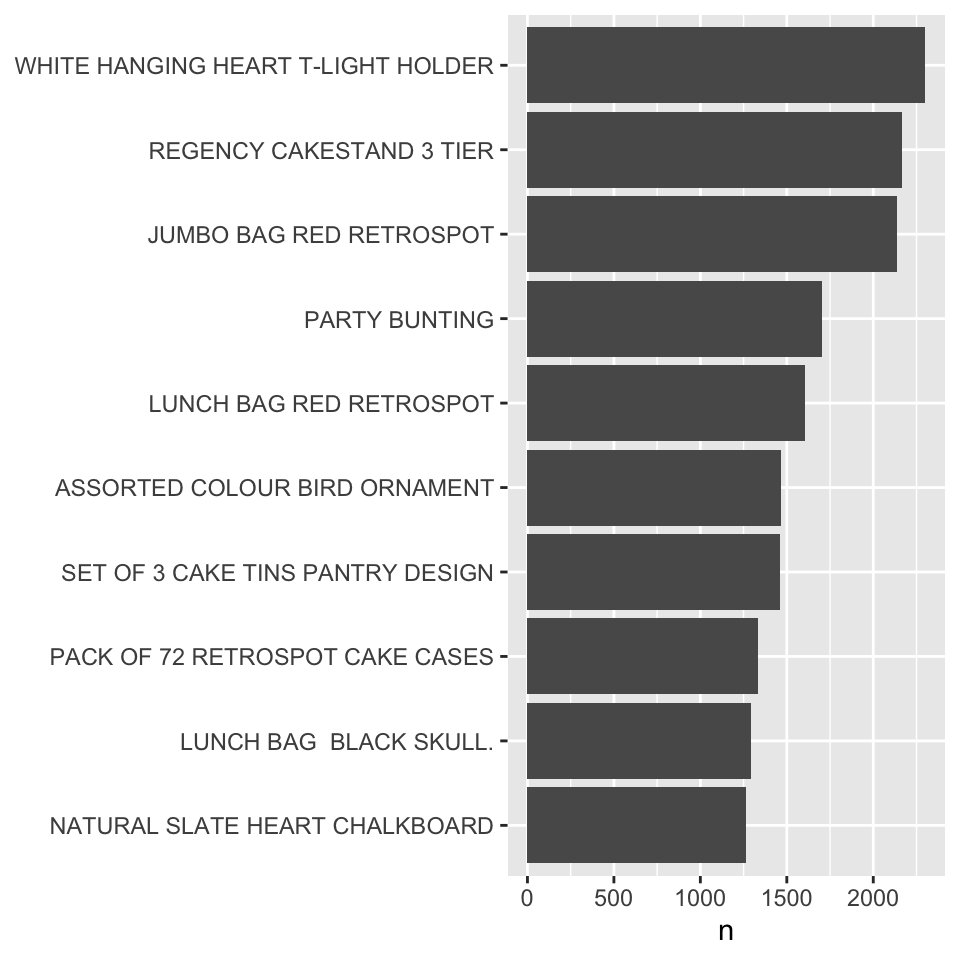

```r
#-----------------------------------------------------------------------#
#-- Find Frequent Itemsets
#-----------------------------------------------------------------------#

#-- get item counts and support for single itemsets
itemFreq = count(X_b, Description, sort=TRUE) %>% mutate(support=n/Nunber_of_Transactions)

# plot top 20
itemFreq %>% slice(1:10) %>%
  ggplot(aes(fct_reorder(Description, n), n)) + # order bars by n
  geom_col() +         # barplot
  coord_flip() +       # rotate plot 90 deg
  theme(axis.title.y = element_blank()) # remove y axis title
```

6. Find the *frequent itemsets* that contain at least 3 items and have $s\geq 0.02$. Add the *lift* metric. Show the top 10 results, ordered by *lift*.

```r
#library(arulesViz)

#-- Convert apriori object to data frame / tibble
# use this instead of inspect(), which only prints to screen
apriori2df <- function(x){
  if(class(x) == "itemsets"){
    out = data.frame(items=arules::labels(x), x@quality, stringsAsFactors = FALSE)
  }
  else if(class(x) == "rules"){
    out = data.frame(
      lhs = arules::labels(lhs(x)),
      rhs = arules::labels(rhs(x)),
      x@quality,
      stringsAsFactors = FALSE)
  }
  else stop("Only works with class of itemsets or rules")
  if(require(tibble)) as_tibble(out) else out
}
```

```r
fis2 = apriori(trans,
               parameter = list(support = .02, minlen=3, target="frequent"))
```

```
#> Apriori
#>
#> Parameter specification:
#>  confidence minval smax arem  aval originalSupport maxtime support minlen
#>          NA    0.1    1 none FALSE            TRUE       5    0.02      3
#>  maxlen            target  ext
#>      10 frequent itemsets TRUE
#>
#> Algorithmic control:
#>  filter tree heap memopt load sort verbose
#>     0.1 TRUE TRUE  FALSE TRUE    2    TRUE
#>
#> Absolute minimum support count: 488
#>
#> set item appearances ...[0 item(s)] done [0.00s].
#> set transactions ...[4211 item(s), 24446 transaction(s)] done [0.19s].
#> sorting and recoding items ... [202 item(s)] done [0.01s].
#> creating transaction tree ... done [0.01s].
#> checking subsets of size 1 2 3 done [0.01s].
#> sorting transactions ... done [0.00s].
#> writing ... [1 set(s)] done [0.00s].
#> creating S4 object  ... done [0.01s].
```

```r
#apriori2df(fis2) %>% arrange(-support)  # order by support (largest to smallest)

#-- Add lift using the interestMeasure() function
apriori2df(fis2) %>%
  mutate(lift = interestMeasure(fis2, measure="lift", trans)) %>%
  arrange(-lift)
```

```
#> # A tibble: 1 x 5
#>   items                                  support transIdenticalToIt… count  lift
#>   <chr>                                    <dbl>               <dbl> <int> <dbl>
#> 1 {GREEN REGENCY TEACUP AND SAUCER,PINK…  0.0225            0.000941   549  346.
```

7. Find all of the *association rules* with $s \geq 0.02$, $c \geq 0.70$. Add the *PS/leverage* and *addedValue* metrics. Show all results, ordered by *addedValue*

```r
#-- Find association rules with support>=.001 and confidence>=.50
rules = apriori(trans,
             parameter = list(support=.02, confidence=.7,
                              target="rules")) # minlen=3,
```

```
#> Apriori
#>
#> Parameter specification:
#>  confidence minval smax arem  aval originalSupport maxtime support minlen
#>         0.7    0.1    1 none FALSE            TRUE       5    0.02      1
#>  maxlen target  ext
#>      10  rules TRUE
#>
#> Algorithmic control:
#>  filter tree heap memopt load sort verbose
#>     0.1 TRUE TRUE  FALSE TRUE    2    TRUE
#>
#> Absolute minimum support count: 488
#>
#> set item appearances ...[0 item(s)] done [0.00s].
#> set transactions ...[4211 item(s), 24446 transaction(s)] done [0.15s].
#> sorting and recoding items ... [202 item(s)] done [0.01s].
#> creating transaction tree ... done [0.01s].
#> checking subsets of size 1 2 3 done [0.01s].
#> writing ... [8 rule(s)] done [0.00s].
#> creating S4 object  ... done [0.01s].
```

```r
#apriori2df(rules) %>% arrange(-confidence)  # order by confidence metric
#apriori2df(rules) %>% arrange(-lift)        # order by lift metric
#-- Add other interest measures
apriori2df(rules) %>%
  mutate(addedValue = interestMeasure(rules, measure="addedValue", trans),
         PS = interestMeasure(rules, measure="leverage", trans)) %>%
  arrange(-addedValue)
```

```
#> # A tibble: 8 x 9
#>   lhs          rhs     support confidence coverage  lift count addedValue     PS
#>   <chr>        <chr>     <dbl>      <dbl>    <dbl> <dbl> <int>      <dbl>  <dbl>
#> 1 {PINK REGEN… {GREEN…  0.0225      0.894   0.0251  20.7   549      0.851 0.0214
#> 2 {GREEN REGE… {ROSES…  0.0225      0.852   0.0263  18.6   549      0.807 0.0213
#> 3 {PINK REGEN… {GREEN…  0.0263      0.804   0.0328  18.6   644      0.761 0.0249
#> 4 {PINK REGEN… {ROSES…  0.0251      0.767   0.0328  16.7   614      0.721 0.0236
#> 5 {GREEN REGE… {ROSES…  0.0321      0.742   0.0432  16.2   784      0.696 0.0301
#> 6 {GARDENERS … {GARDE…  0.0225      0.718   0.0313  19.0   549      0.680 0.0213
#> 7 {GREEN REGE… {PINK …  0.0225      0.700   0.0321  21.4   549      0.667 0.0214
#> 8 {ROSES REGE… {GREEN…  0.0321      0.7     0.0458  16.2   784      0.657 0.0301
```

8. Find one rule that you think is interesting. Write the rule and explain why you find it interesting.

```r
# my rule
# find all

#-- Find association rules with support>=.01 and confidence>=.50
rules = apriori(trans,
             parameter = list(support=.01, confidence=.90,
                              target="rules")) # minlen=3,
```

```
#> Apriori
#>
#> Parameter specification:
#>  confidence minval smax arem  aval originalSupport maxtime support minlen
#>         0.9    0.1    1 none FALSE            TRUE       5    0.01      1
#>  maxlen target  ext
#>      10  rules TRUE
#>
#> Algorithmic control:
#>  filter tree heap memopt load sort verbose
#>     0.1 TRUE TRUE  FALSE TRUE    2    TRUE
#>
#> Absolute minimum support count: 244
#>
#> set item appearances ...[0 item(s)] done [0.00s].
#> set transactions ...[4211 item(s), 24446 transaction(s)] done [0.17s].
#> sorting and recoding items ... [639 item(s)] done [0.01s].
#> creating transaction tree ... done [0.01s].
#> checking subsets of size 1 2 3 4 done [0.03s].
#> writing ... [3 rule(s)] done [0.00s].
#> creating S4 object  ... done [0.00s].
```

```r
#apriori2df(rules) %>% arrange(-confidence)  # order by confidence metric
#apriori2df(rules) %>% arrange(-lift)        # order by lift metric
#-- Add other interest measures
apriori2df(rules) %>%
  mutate(addedValue = interestMeasure(rules, measure="addedValue", trans),
         PS = interestMeasure(rules, measure="leverage", trans)) %>%
  arrange(-addedValue)
```

```
#> # A tibble: 3 x 9
#>   lhs          rhs    support confidence coverage  lift count addedValue      PS
#>   <chr>        <chr>    <dbl>      <dbl>    <dbl> <dbl> <int>      <dbl>   <dbl>
#> 1 {REGENCY TE… {REGE…  0.0106      0.949   0.0111  60.1   258      0.933 0.0104
#> 2 {REGENCY TE… {REGE…  0.0106      0.915   0.0115  48.9   258      0.896 0.0103
#> 3 {CHARLOTTE … {RED …  0.0101      0.905   0.0112  21.1   247      0.862 0.00962
```

```r
#
# The conﬁdence of a rule is an estimate of the conditional probability of J being in a basket given the basket already contains I
```

in this rule, I’m trying to find supper larger than 0.01 and a confidence of larger than 0.9. I found it interesting because we can see there are small customers when they buy TEA PLATE, they tend to buy PINK with ROSES color together, and GREEN with PINK together and some customer buy CHARLOTTE BAG tend to buy a 3 with PINK PLOKADOT, SUKI DESING and STRAWBERRY

reference: participated in a group meeting hosted in slacks.